# Dereplication feasibility – all 25 participants

2026-09-10

## Context

Same-participant longitudinal metagenomics (25 participants: 19 with both a pooled co-assembly and multiple single-sample assemblies, 6 with single-sample assemblies only) means a lot of the sequence assembled and annotated across samples is likely near-identical repeat, not independent new information. This report tests that directly with `mmseqs2` clustering at two levels – contigs (Tier 1, feeds geNomad/MAP’s contig-level tools) and ORFs/genes (Tier 2, feeds funcscan’s AMR/AMP/CAZyme tools) – across all 25 participants, then cross-checks the core assumption (that clustered = safe to annotate once and propagate) against already-computed real production annotation (RGI, geNomad), with no new annotation compute. See `dereplication_brainstorm.md` for the original design and `dereplication_pilot_results.md` for the 2-participant pilot this scales up.

## 1. Redundancy overview, all 25 participants

```r
overview %>%
  mutate(tier = factor(tier, levels = c("contigs", "orfs"))) %>%
  arrange(tier, participant) %>%
  transmute(
    Participant = participant, Tier = tier,
    `Total sequences` = format(total_seqs, big.mark = ","),
    `Redundant (count %)` = redundant_pct,
    `Redundant (bp %)` = redundant_bp_pct
  ) %>%
  kable(digits = 1)
```

| Participant | Tier | Total sequences | Redundant (count %) | Redundant (bp %) |
| --- | --- | --- | --- | --- |
| p110 | contigs | 174,051 | 43.9 | 71.4 |
| p125 | contigs | 203,340 | 42.9 | 71.9 |
| p142 | contigs | 316,663 | 41.1 | 68.9 |
| p151 | contigs | 169,169 | 26.6 | 57.6 |
| p292 | contigs | 336,223 | 41.8 | 70.2 |
| p341 | contigs | 228,937 | 48.2 | 74.5 |
| p373 | contigs | 179,040 | 35.3 | 67.8 |
| p398 | contigs | 158,607 | 44.3 | 72.6 |
| p408 | contigs | 158,291 | 40.3 | 72.7 |
| p431 | contigs | 786,990 | 49.7 | 75.5 |
| p470 | contigs | 277,388 | 42.0 | 70.7 |
| p523 | contigs | 384,468 | 39.4 | 68.2 |
| p550 | contigs | 184,904 | 46.5 | 71.7 |
| p584 | contigs | 157,910 | 43.8 | 71.8 |
| p601 | contigs | 321,636 | 42.5 | 71.6 |
| p644 | contigs | 291,512 | 37.2 | 69.1 |
| p654 | contigs | 128,904 | 35.2 | 66.9 |
| p722 | contigs | 193,435 | 48.7 | 74.0 |
| p728 | contigs | 212,925 | 43.7 | 75.8 |
| p729 | contigs | 227,935 | 36.7 | 67.7 |
| p789 | contigs | 559,284 | 42.6 | 68.0 |
| p813 | contigs | 1,063,161 | 48.2 | 74.4 |
| p860 | contigs | 292,785 | 40.4 | 71.3 |
| p894 | contigs | 168,807 | 44.9 | 72.0 |
| p97 | contigs | 191,613 | 42.0 | 73.3 |
| p110 | orfs | 1,022,879 | 93.2 | 96.0 |
| p125 | orfs | 1,220,786 | 93.9 | 96.0 |
| p142 | orfs | 1,673,832 | 89.3 | 91.7 |
| p151 | orfs | 923,624 | 75.5 | 78.9 |
| p292 | orfs | 1,891,875 | 93.7 | 95.9 |
| p341 | orfs | 1,400,430 | 94.0 | 95.9 |
| p373 | orfs | 1,124,585 | 88.1 | 90.6 |
| p398 | orfs | 1,024,662 | 95.0 | 96.9 |
| p408 | orfs | 1,044,062 | 95.0 | 97.0 |
| p431 | orfs | 4,308,969 | 96.2 | 97.6 |
| p470 | orfs | 1,588,727 | 95.2 | 96.9 |
| p523 | orfs | 2,027,566 | 94.3 | 96.4 |
| p550 | orfs | 1,047,675 | 93.8 | 95.9 |
| p584 | orfs | 998,607 | 93.7 | 95.6 |
| p601 | orfs | 1,945,886 | 95.2 | 97.0 |
| p644 | orfs | 1,675,641 | 95.0 | 96.7 |
| p654 | orfs | 842,257 | 88.8 | 90.5 |
| p722 | orfs | 1,186,746 | 94.5 | 96.9 |
| p728 | orfs | 1,546,969 | 96.3 | 98.0 |
| p729 | orfs | 1,252,361 | 89.1 | 92.0 |
| p789 | orfs | 2,851,725 | 94.1 | 96.3 |
| p813 | orfs | 5,868,100 | 96.5 | 97.9 |
| p860 | orfs | 1,741,929 | 95.2 | 97.1 |
| p894 | orfs | 925,185 | 92.9 | 95.7 |
| p97 | orfs | 1,286,297 | 96.5 | 98.0 |

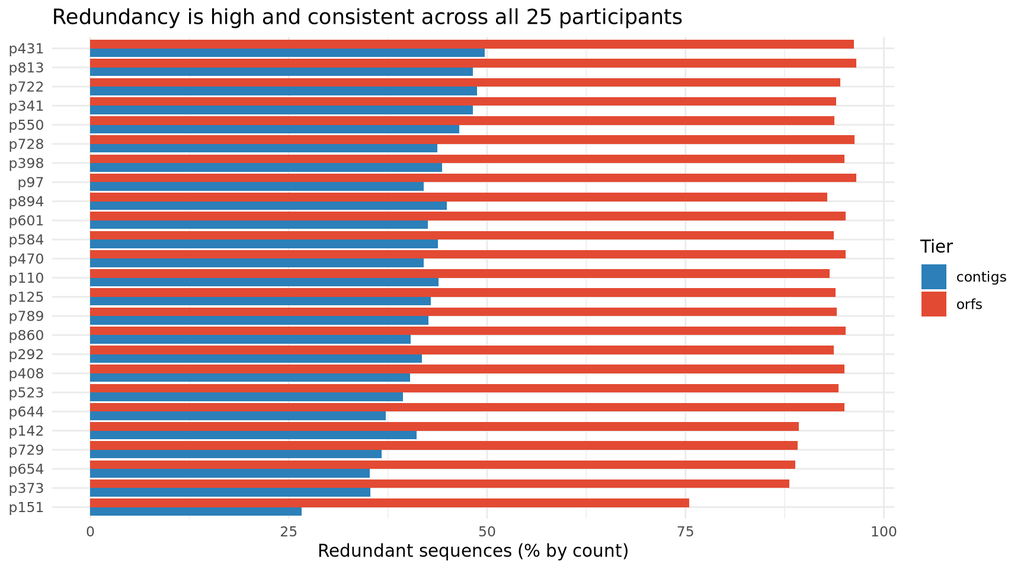

```r
ggplot(overview, aes(x = reorder(participant, redundant_pct), y = redundant_pct, fill = tier)) +
  geom_col(position = "dodge") +
  scale_fill_manual(values = pal) +
  coord_flip() +
  labs(x = NULL, y = "Redundant sequences (% by count)", fill = "Tier",
       title = "Redundancy is high and consistent across all 25 participants") +
  theme_minimal()
```